# Project: Investigate Imdb Movie Dataset

- Introduction
- Data Wrangling

. Number of Empty Rows  
. Number of 0s for Each Column  
. Number of Unique Values for Each Column  
. Check Columns' Datatype  
. Drop Irrelevant Columns  
. Delete Duplicate Rows  
. Fix Datatypes  
. Trim Data Entries  
. Create Datasets & Drop Nan Values  
. Fix Multiple-value Data Entries  
. Fix Zero Values

- Exploratory Data Analysis

. Question 1  
. Question 2

- Conclusions

# Introduction

**IMDB Movie Data:**  
This dataset contains information about 10,000 movies collected from The Movie Database (TMDb),including user ratings and revenue. Not all features are relevant to the questions this analysis is to answer. Therefore, a few will be taken out. Data provided by [Udacity](https://d17h27t6h515a5.cloudfront.net/topher/2017/October/59dd1c4c_tmdb-movies/tmdb-movies.csv)  
Original data provided by [Kaggle](https://www.kaggle.com/tmdb/tmdb-movie-metadata)

**Dataset features:**

- id,
- imdb_id,
- popularity,
- budget,
- revenue,
- original_title,
- cast,
- homepage,
- director,
- tagline,
- keywords,
- overview,
- runtime,
- genres,
- production_companies,
- release_date,
- vote_count,
- vote_average,
- release_year,
- budget_adj*,
- revenue_adj  
  **The final two columns ending with “_adj” show the budget and revenue of the associated movie in terms of 2010 dollars, accounting for inflation over time.

Further on data will be explored and analysed to andwer two questions.

**Question 1: Is it worth the time to watch movies?* If so, when picking a movie how would one know they won't be disappointed?Conclusion**

What are the chances of ending up with a good movie? Insight

Does it matter when the movie was produced? Insight

Which genre(s) are associated with good movies? Insight

> **It is assumed that you have no prior knowledge about movies. And want to randomly pick a movie out of a list.*

**Question 2: Is it a good idea to invest in movie production? If so, how to maximise your chances of success?Conclusion</strong>**

What are the chances of succeeding?Insight

Does initial investment guarantee financial success?Insight

Does content quality bring in more profit? Insight

Which genre(s) are the safest/best bet for investment? Insight

```python
import pandas as pd
import numpy as np
import matplotlib.pyplot as plt
import seaborn as sns
from datetime import datetime as dt
%matplotlib inline
```

# Data Wrangling

In this section data is loaded, checked for cleanliness, and then trimed and cleaned for analysis.

```python
df_raw_data = pd.read_csv('../../Datasets/movies.csv')
df_raw_data.head(2)
```

|  | id | imdb_id | popularity | budget | revenue | original_title | cast | homepage | director | tagline | ... | overview | runtime | genres | production_companies | release_date | vote_count | vote_average | release_year | budget_adj | revenue_adj |
| --- | --- | --- | --- | --- | --- | --- | --- | --- | --- | --- | --- | --- | --- | --- | --- | --- | --- | --- | --- | --- | --- |
| 0 | 135397 | tt0369610 | 32.985763 | 150000000 | 1513528810 | Jurassic World | Chris Pratt\|Bryce Dallas Howard\|Irrfan Khan\|Vi... | http://www.jurassicworld.com/ | Colin Trevorrow | The park is open. | ... | Twenty-two years after the events of Jurassic ... | 124 | Action\|Adventure\|Science Fiction\|Thriller | Universal Studios\|Amblin Entertainment\|Legenda... | 6/9/15 | 5562 | 6.5 | 2015 | 1.379999e+08 | 1.392446e+09 |
| 1 | 76341 | tt1392190 | 28.419936 | 150000000 | 378436354 | Mad Max: Fury Road | Tom Hardy\|Charlize Theron\|Hugh Keays-Byrne\|Nic... | http://www.madmaxmovie.com/ | George Miller | What a Lovely Day. | ... | An apocalyptic story set in the furthest reach... | 120 | Action\|Adventure\|Science Fiction\|Thriller | Village Roadshow Pictures\|Kennedy Miller Produ... | 5/13/15 | 6185 | 7.1 | 2015 | 1.379999e+08 | 3.481613e+08 |

2 rows × 21 columns

```python
print('Dataset consist of {} rows and {} columns.'.format(df_raw_data.shape[0],df_raw_data.shape[1]))
```

```
Dataset consist of 10866 rows and 21 columns.
```

**Number of Duplicates**

```python
print('Of {} rows, {} are unique and {} is a duplicate.'.format(df_raw_data.shape[0],df_raw_data.id.nunique(),df_raw_data.duplicated().sum()))
```

```
Of 10866 rows, 10865 are unique and 1 is a duplicate.
```

**Number of Missing Values for Each Column**

```python
pd.DataFrame(df_raw_data.isna().sum()).transpose()
```

|  | id | imdb_id | popularity | budget | revenue | original_title | cast | homepage | director | tagline | ... | overview | runtime | genres | production_companies | release_date | vote_count | vote_average | release_year | budget_adj | revenue_adj |
| --- | --- | --- | --- | --- | --- | --- | --- | --- | --- | --- | --- | --- | --- | --- | --- | --- | --- | --- | --- | --- | --- |
| 0 | 0 | 10 | 0 | 0 | 0 | 0 | 76 | 7930 | 44 | 2824 | ... | 4 | 0 | 23 | 1030 | 0 | 0 | 0 | 0 | 0 | 0 |

1 rows × 21 columns

**Number of Empty Rows**

```python
df_raw_data.isna().all(1).sum()
```

```
0
```

**Number of 0s for Each Column**

```python
pd.DataFrame(df_raw_data.eq(0).sum()).transpose()
```

|  | id | imdb_id | popularity | budget | revenue | original_title | cast | homepage | director | tagline | ... | overview | runtime | genres | production_companies | release_date | vote_count | vote_average | release_year | budget_adj | revenue_adj |
| --- | --- | --- | --- | --- | --- | --- | --- | --- | --- | --- | --- | --- | --- | --- | --- | --- | --- | --- | --- | --- | --- |
| 0 | 0 | 0 | 0 | 5696 | 6016 | 0 | 0 | 0 | 0 | 0 | ... | 0 | 31 | 0 | 0 | 0 | 0 | 0 | 0 | 5696 | 6016 |

1 rows × 21 columns

**Number of Unique Values for Each Column**  
Although this information is not of importance for every column, it helps us ensure not more than one entry is made fore one movie.

```python
pd.DataFrame(df_raw_data.nunique()).transpose()
```

|  | id | imdb_id | popularity | budget | revenue | original_title | cast | homepage | director | tagline | ... | overview | runtime | genres | production_companies | release_date | vote_count | vote_average | release_year | budget_adj | revenue_adj |
| --- | --- | --- | --- | --- | --- | --- | --- | --- | --- | --- | --- | --- | --- | --- | --- | --- | --- | --- | --- | --- | --- |
| 0 | 10865 | 10855 | 10814 | 557 | 4702 | 10571 | 10719 | 2896 | 5067 | 7997 | ... | 10847 | 247 | 2039 | 7445 | 5909 | 1289 | 72 | 56 | 2614 | 4840 |

1 rows × 21 columns

```python
df_raw_data[['original_title','director','cast']].duplicated().sum()
```

```
2
```

> At first glance, number of unique value for `original_title` suggests that we have duplicate entries. However, running the code above explains that there are different movies with the same name.Moreover, it suggests that we have one more duplicate row that perhaps was not detected by `duplicated()` earlier du to a difference in one of the columns' entry.

**Check Columns' Datatype**

```python
df_raw_data.info()
```

```
<class 'pandas.core.frame.DataFrame'>
RangeIndex: 10866 entries, 0 to 10865
Data columns (total 21 columns):
 #   Column                Non-Null Count  Dtype
---  ------                --------------  -----
 0   id                    10866 non-null  int64
 1   imdb_id               10856 non-null  object
 2   popularity            10866 non-null  float64
 3   budget                10866 non-null  int64
 4   revenue               10866 non-null  int64
 5   original_title        10866 non-null  object
 6   cast                  10790 non-null  object
 7   homepage              2936 non-null   object
 8   director              10822 non-null  object
 9   tagline               8042 non-null   object
 10  keywords              9373 non-null   object
 11  overview              10862 non-null  object
 12  runtime               10866 non-null  int64
 13  genres                10843 non-null  object
 14  production_companies  9836 non-null   object
 15  release_date          10866 non-null  object
 16  vote_count            10866 non-null  int64
 17  vote_average          10866 non-null  float64
 18  release_year          10866 non-null  int64
 19  budget_adj            10866 non-null  float64
 20  revenue_adj           10866 non-null  float64
dtypes: float64(4), int64(6), object(11)
memory usage: 1.7+ MB
```

> Datatype for `release_date` should change to `datetime`.

**Data Cleaning and Triming**

**Drop Irrelevant Columns**

```python
df_raw_data.drop(['imdb_id','popularity','homepage','tagline','overview','budget','revenue'],axis =1, inplace = True)
```

**Delete Duplicate Rows**

```python
df_raw_data.drop_duplicates(inplace = True)
print('Number of duplicate rows: {}'.format(df_raw_data.duplicated().sum()))
```

```
Number of duplicate rows: 0
```

```python
#Drop rows with entries on the same film
df_raw_data[df_raw_data[['original_title','director','cast']].duplicated()]
```

|  | id | original_title | cast | director | keywords | runtime | genres | production_companies | release_date | vote_count | vote_average | release_year | budget_adj | revenue_adj |
| --- | --- | --- | --- | --- | --- | --- | --- | --- | --- | --- | --- | --- | --- | --- |
| 6701 | 16781 | Madea's Family Reunion | Tyler Perry\|Blair Underwood\|Lynn Whitfield\|Bor... | Tyler Perry | spanking\|based on play | 110 | Drama\|Comedy\|Romance | Lions Gate Films | 2/24/06 | 63 | 6.0 | 2006 | 6.490015e+06 | 6.190557e+07 |

```python
df_raw_data[df_raw_data['original_title'] == "Madea's Family Reunion"]
```

|  | id | original_title | cast | director | keywords | runtime | genres | production_companies | release_date | vote_count | vote_average | release_year | budget_adj | revenue_adj |
| --- | --- | --- | --- | --- | --- | --- | --- | --- | --- | --- | --- | --- | --- | --- |
| 4063 | 28004 | Madea's Family Reunion | Tyler Perry\|Blair Underwood\|Lynn Whitfield\|Bor... | Tyler Perry | NaN | 0 | Comedy | NaN | 1/25/02 | 49 | 5.9 | 2002 | 7.273568e+06 | 0.000000e+00 |
| 6701 | 16781 | Madea's Family Reunion | Tyler Perry\|Blair Underwood\|Lynn Whitfield\|Bor... | Tyler Perry | spanking\|based on play | 110 | Drama\|Comedy\|Romance | Lions Gate Films | 2/24/06 | 63 | 6.0 | 2006 | 6.490015e+06 | 6.190557e+07 |

```python
df_raw_data.drop([4063],axis = 0, inplace = True)
df_raw_data[df_raw_data['original_title'] == "Madea's Family Reunion"]
```

|  | id | original_title | cast | director | keywords | runtime | genres | production_companies | release_date | vote_count | vote_average | release_year | budget_adj | revenue_adj |
| --- | --- | --- | --- | --- | --- | --- | --- | --- | --- | --- | --- | --- | --- | --- |
| 6701 | 16781 | Madea's Family Reunion | Tyler Perry\|Blair Underwood\|Lynn Whitfield\|Bor... | Tyler Perry | spanking\|based on play | 110 | Drama\|Comedy\|Romance | Lions Gate Films | 2/24/06 | 63 | 6.0 | 2006 | 6.490015e+06 | 6.190557e+07 |

**Fix Datatypes**

**Column `release_date`**  
Datatype for release date is string. It should be converted to datetime.

```python
df_raw_data.release_date = df_raw_data.release_date.apply(lambda d: d.replace(d,d[:-2]))+ df_raw_data.release_year.astype(str)
df_raw_data.release_date = pd.to_datetime(df_raw_data.release_date)
df_raw_data.release_date
```

```
0       2015-06-09
1       2015-05-13
2       2015-03-18
3       2015-12-15
4       2015-04-01
           ...
10861   1966-06-15
10862   1966-12-21
10863   1966-01-01
10864   1966-11-02
10865   1966-11-15
Name: release_date, Length: 10864, dtype: datetime64[ns]
```

**Trim data entries**

**Remove white space**

```python
for col in df_raw_data.columns:
    if df_raw_data[col].dtype == str:
        df_raw_data[col] = df_raw_data[col].str.strip().copy()
```

**Fix columns with multipl-value data entries**

**Columns `cast`, `keywords`, `genres`, `production_companies`** A number of columns have more than one entry for each record. For example column `cast`contains names of several actors separated by `'|'`. This will make it difficult to efficiently analyse the data based on one specific entry. Let's say, we want to have a range of info on movies that have actor 'X' featuring. Current structure of data does not accomodate that easily. Therefore, the entries should be splitted.

```python
df_raw_data[['cast','keywords','genres','production_companies']].head(3)
```

|  | cast | keywords | genres | production_companies |
| --- | --- | --- | --- | --- |
| 0 | Chris Pratt\|Bryce Dallas Howard\|Irrfan Khan\|Vi... | monster\|dna\|tyrannosaurus rex\|velociraptor\|island | Action\|Adventure\|Science Fiction\|Thriller | Universal Studios\|Amblin Entertainment\|Legenda... |
| 1 | Tom Hardy\|Charlize Theron\|Hugh Keays-Byrne\|Nic... | future\|chase\|post-apocalyptic\|dystopia\|australia | Action\|Adventure\|Science Fiction\|Thriller | Village Roadshow Pictures\|Kennedy Miller Produ... |
| 2 | Shailene Woodley\|Theo James\|Kate Winslet\|Ansel... | based on novel\|revolution\|dystopia\|sequel\|dyst... | Adventure\|Science Fiction\|Thriller | Summit Entertainment\|Mandeville Films\|Red Wago... |

> *Given the size of dataset, to make the process faster the dataset is to be devided into a number of subd-atasets(tables) which later, depending on the requirements of the analysis,will be merged. Consequently, handling null and 0 values will be more pragmatic this way

**Create movie_dataset**

```python
df_movies = df_raw_data[['id', 'original_title','release_date','release_year','runtime','vote_average','budget_adj','revenue_adj']].copy()
print('Number of Nan entries : {}\nNumber of 0 entries: {} to be found in columns: {}'.format(df_movies.isna().sum().sum(),df_movies.eq(0).sum().sum(),list(df_movies.columns[df_movies.eq(0).any() == True])))
```

```
Number of Nan entries : 0
Number of 0 entries: 11741 to be found in columns: ['runtime', 'budget_adj', 'revenue_adj']
```

> In order to fix this, 0 values will be replace by the average value of each feature for each genre. Therefore, this will be fixed once the data entries for column `genres` are fixed.

```python
df_movies.to_csv('../../Datasets/movies_dataset.csv', index = False)
df_movies.head(2)
```

|  | id | original_title | release_date | release_year | runtime | vote_average | budget_adj | revenue_adj |
| --- | --- | --- | --- | --- | --- | --- | --- | --- |
| 0 | 135397 | Jurassic World | 2015-06-09 | 2015 | 124 | 6.5 | 1.379999e+08 | 1.392446e+09 |
| 1 | 76341 | Mad Max: Fury Road | 2015-05-13 | 2015 | 120 | 7.1 | 1.379999e+08 | 3.481613e+08 |

**Create actors_dataset**

```python
df_actors = df_raw_data[['id','cast']].copy()
print('Number of Nan entries : {}\nNumber of 0 entries: {} '.format(df_actors.isna().sum().sum(),df_actors.eq(0).sum().sum()))
```

```
Number of Nan entries : 76
Number of 0 entries: 0
```

```python
df_actors.dropna(axis = 0, inplace = True)
df_actors.rename(columns = {'cast':'actor'}, inplace = True)
df_actors.to_csv('../../Datasets/df_actors.csv', index = False)
```

> column's name changed from `cast`to `actor`

```python
df_actors.head(2)
```

|  | id | actor |
| --- | --- | --- |
| 0 | 135397 | Chris Pratt\|Bryce Dallas Howard\|Irrfan Khan\|Vi... |
| 1 | 76341 | Tom Hardy\|Charlize Theron\|Hugh Keays-Byrne\|Nic... |

**Create genres_dataset**

```python
df_genres = df_raw_data[['id','genres']].copy()
df_genres.rename(columns = {'genres':'genre'}, inplace = True)
print('Number of Nan entries : {}\nNumber of 0 entries: {} '.format(df_genres.isna().sum().sum(),df_genres.eq(0).sum().sum()))
```

```
Number of Nan entries : 23
Number of 0 entries: 0
```

```python
df_genres.dropna(axis = 0, inplace = True)
df_genres.to_csv('../../Datasets/genres_dataset.csv', index = False)
```

> column's name changed from `genres`to `genre`

```python
df_genres.head(2)
```

|  | id | genre |
| --- | --- | --- |
| 0 | 135397 | Action\|Adventure\|Science Fiction\|Thriller |
| 1 | 76341 | Action\|Adventure\|Science Fiction\|Thriller |

**Create keywords_dataset**

```python
df_keywords = df_raw_data[['id','keywords']].copy()
print('Number of Nan entries : {}\nNumber of 0 entries: {} '.format(df_keywords.isna().sum().sum(),df_keywords.eq(0).sum().sum()))
```

```
Number of Nan entries : 1492
Number of 0 entries: 0
```

```python
df_keywords.dropna(axis = 0, inplace = True)
df_keywords.rename(columns = {'keywords':'keyword'}, inplace = True)
df_keywords.to_csv('../../Datasets/df_keywords.csv', index = False)
```

> column's name changed from `keywords`to `keyword`

```python
df_keywords.head(2)
```

|  | id | keyword |
| --- | --- | --- |
| 0 | 135397 | monster\|dna\|tyrannosaurus rex\|velociraptor\|island |
| 1 | 76341 | future\|chase\|post-apocalyptic\|dystopia\|australia |

**Create production_companies_dataset**

```python
df_production_companies = df_raw_data[['id','production_companies']].copy()
print('Number of Nan entries : {}\nNumber of 0 entries: {} '.format(df_production_companies.isna().sum().sum(),df_production_companies.eq(0).sum().sum()))
```

```
Number of Nan entries : 1029
Number of 0 entries: 0
```

```python
df_production_companies.dropna(axis = 0, inplace = True)
df_production_companies.rename(columns = {'production_companies':'production_company'}, inplace = True)
df_production_companies.to_csv('../../Datasets/df_production_companies.csv', index = False)
```

> column's name changed from `production_companies`to `production_company`

```python
df_production_companies.head(2)
```

|  | id | production_company |
| --- | --- | --- |
| 0 | 135397 | Universal Studios\|Amblin Entertainment\|Legenda... |
| 1 | 76341 | Village Roadshow Pictures\|Kennedy Miller Produ... |

**Function: fix multiple-value data entries**

```python
def split_data (input_dataframe, column_to_trim):
    df_to_trim = input_dataframe[input_dataframe[column_to_trim].str.find('|') != -1].copy()
    df_temp = input_dataframe.copy()
    ind = df_to_trim.index
    for i in ind:
        record_to_fix = df_temp.loc[i].copy()
        df_temp.drop([i], axis = 0, inplace = True)
        temp = record_to_fix.copy()
        for j in range(record_to_fix[column_to_trim].count('|')+1):
            temp[column_to_trim] = record_to_fix[column_to_trim].split('|')[j]
            df_temp = df_temp.append(temp)
    return df_temp
```

**Trim data**

```python
df_actors_trimmed = split_data(df_actors,'actor')
df_actors_trimmed.to_csv('../../Datasets/actors_dataset_trimmed.csv', index = False)
df_genres_trimmed = split_data(df_genres, 'genre')
df_genres_trimmed.to_csv('../../Datasets/genres_dataset_trimmed.csv', index = False)
df_production_co_trimmed = split_data(df_production_companies, 'production_company')
df_production_co_trimmed.to_csv('../../Datasets/production_companies_dataset_trimmed.csv', index = False)
df_keywords_trimmed = split_data(df_keywords, 'keyword')
df_keywords_trimmed.to_csv('../../Datasets/keywords_dataset_trimmed.csv', index = False)
```

```python
df_actors = pd.read_csv('../../Datasets/actors_dataset_trimmed.csv')
df_genres = pd.read_csv('../../Datasets/genres_dataset_trimmed.csv')
df_production_companies = pd.read_csv('../../Datasets/production_companies_dataset_trimmed.csv')
df_keywords= pd.read_csv('../../Datasets/keywords_dataset_trimmed.csv')
```

```python
df_actors[(df_actors.id==135397) | (df_actors.id==76341)]
```

|  | id | actor |
| --- | --- | --- |
| 144 | 135397 | Chris Pratt |
| 145 | 135397 | Bryce Dallas Howard |
| 146 | 135397 | Irrfan Khan |
| 147 | 135397 | Vincent D'Onofrio |
| 148 | 135397 | Nick Robinson |
| 149 | 76341 | Tom Hardy |
| 150 | 76341 | Charlize Theron |
| 151 | 76341 | Hugh Keays-Byrne |
| 152 | 76341 | Nicholas Hoult |
| 153 | 76341 | Josh Helman |

```python
df_genres[(df_genres.id==135397) | (df_genres.id==76341)]
```

|  | id | genre |
| --- | --- | --- |
| 2327 | 135397 | Action |
| 2328 | 135397 | Adventure |
| 2329 | 135397 | Science Fiction |
| 2330 | 135397 | Thriller |
| 2331 | 76341 | Action |
| 2332 | 76341 | Adventure |
| 2333 | 76341 | Science Fiction |
| 2334 | 76341 | Thriller |

```python
df_production_companies[(df_production_companies.id==135397) | (df_production_companies.id==76341)]
```

|  | id | production_company |
| --- | --- | --- |
| 3440 | 135397 | Universal Studios |
| 3441 | 135397 | Amblin Entertainment |
| 3442 | 135397 | Legendary Pictures |
| 3443 | 135397 | Fuji Television Network |
| 3444 | 135397 | Dentsu |
| 3445 | 76341 | Village Roadshow Pictures |
| 3446 | 76341 | Kennedy Miller Productions |

```python
df_keywords[(df_keywords.id==135397) | (df_keywords.id==76341)]
```

|  | id | keyword |
| --- | --- | --- |
| 931 | 135397 | monster |
| 932 | 135397 | dna |
| 933 | 135397 | tyrannosaurus rex |
| 934 | 135397 | velociraptor |
| 935 | 135397 | island |
| 936 | 76341 | future |
| 937 | 76341 | chase |
| 938 | 76341 | post-apocalyptic |
| 939 | 76341 | dystopia |
| 940 | 76341 | australia |

**Fix 0 values**  
Columns `runtime`, `budget_adj`and `revenue_adj`have considerable number of 0 values that will impact the analysis. 0s will be replace by the average value of each column for each genre.

**Fix 0 values for `runtime`**

```python
def fix_zero_values(column_name):
    df_movies_temp = df_movies[['id',column_name]].copy()
    #genre is saved in a different dataset. merge datasets first
    df_to_fix = pd.merge(df_genres, df_movies_temp,how = 'inner',left_on = 'id', right_on = 'id')
    #take out zeros so the average will not be affected
    df_to_fix_Nonzero = df_to_fix[df_to_fix[column_name] != 0].copy()
    df_to_fix_zero = df_to_fix[df_to_fix[column_name] == 0].copy()
    #calculate average value of the column for each genre
    average_column_value = (df_to_fix_Nonzero.groupby('genre').mean()[column_name])

    #replace zero values
    for i in df_to_fix_zero.index:
        genre = df_to_fix_zero.loc[i,'genre']
        average_value = average_column_value[genre]
        df_to_fix_zero.loc[i,column_name] = average_value

    df_zero_value_fixed = df_to_fix_zero.copy()

    #update values of column_name in movies dataset
    df_movies_index = df_movies[df_movies[column_name] == 0].index
    for i in df_movies_index:
        movie_id = df_movies.loc[i,'id']
        if movie_id in df_zero_value_fixed.id.unique():
            column_value = df_zero_value_fixed[df_zero_value_fixed.id == movie_id][column_name].mean()
            df_movies.loc[i,column_name] = column_value
```

```python
fix_zero_values('runtime')
fix_zero_values('revenue_adj')
fix_zero_values('budget_adj')
print('Number of zero values in runtime columns:',df_movies.runtime.eq(0).sum())
print('Number of zero values in revenue_adj columns:',df_movies.revenue_adj.eq(0).sum())
print('Number of zero values in budget_adj columns:',df_movies.budget_adj.eq(0).sum())
```

```
Number of zero values in runtime columns: 0
Number of zero values in revenue_adj columns: 0
Number of zero values in budget_adj columns: 0
```

```python
revenue_adj_id_list = df_movies.query('revenue_adj == "0"').index
df_movies.drop(revenue_adj_id_list, axis = 0, inplace = True)
print('Number of zero values in revenue_adj columns:',df_movies.revenue_adj.eq(0).sum())
print('Number of zero values in budget_adj columns:',df_movies.budget_adj.eq(0).sum())
```

```
Number of zero values in revenue_adj columns: 0
Number of zero values in budget_adj columns: 0
```

```python
df_movies.runtime = df_movies.runtime.astype(int)
```

```python
df_movies.to_csv('../../Datasets/movies_dataset.csv',index = False)
```

# Exploratory Data Analysis

In this section data is explored to extract insight and answer question.

## Question 1: Is it worth the time to watch movies? If so, when picking a movie how would one know they won't be disappointed?

. **What are the chances of ending up with a good movie?**</strong>  
. **Does it matter when the movie was produced?**</strong>  
. **Which genre(s) are associated with good movies?** </strong>

To answer this question, data will be explored with vote_average assigned to each movie. first step would be to label movies as good or bad so as to be able to later group them accordingly and perform the analysis.

```python
df_movies.vote_average.describe()
```

```
count    10841.000000
mean         5.974071
std          0.934299
min          1.500000
25%          5.400000
50%          6.000000
75%          6.600000
max          9.200000
Name: vote_average, dtype: float64
```

```python
#Categorize movies into 'Waste of time', 'Not bad', 'Worth the time' based on vote_average for each movie.
#Each movie will have an entry in a new column 'review'
df_vote_average = df_movies[['id', 'vote_average']].copy()
df_review_temp = df_vote_average.copy()
vote_ranges = [1,5.5, 7, 9.2]
review_labels = ['Waste of time', 'Not bad', 'Worth the time']
df_review_temp['review'] = pd.cut(df_review_temp['vote_average'], bins = vote_ranges, labels = review_labels)
df_movie_name = df_movies[['id','original_title']].copy()
df_review = pd.merge(df_movie_name,df_review_temp,how = 'inner', left_on = 'id', right_on = 'id')
```

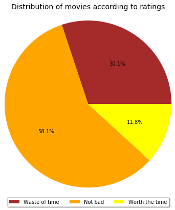

```python
#plot a pie chart that illustrates distribution of movies according to rating
fig6,ax6 = plt.subplots(figsize = (15,5))
movie_count_per_review_label = df_review.groupby('review').id.count()
ax6.pie(movie_count_per_review_label,colors = ['brown','orange','yellow'], radius =1.5, autopct='%1.1f%%')
ax6.set_title('Distribution of movies according to ratings',  size = 14, pad = 50)
plt.legend(labels = ['Waste of time', 'Not bad', 'Worth the time'],loc='upper center', bbox_to_anchor=(0.5, -0.15), fancybox=True, shadow=True,ncol=3);
```

> Odds are (58% chance) that you'll end up with a movie that won't be too bad. But if the odds are not in your favor, chances are you'll end up wastin your time (30%) since a very small number of movies are actually worth the time(12%).

```python
#Categorize release_year into decades 66-76,76-86,86-96... and assing a new entry to each movie at a new column 'decade'
df_release_year = df_movies[['id','release_year']].copy()
decade_labels = ['66-75','76-85','86-95','96-05','06-15']
years_bin = [1965,1976,1986,1996,2006,2016]
df_release_year['decade'] = pd.cut(df_release_year['release_year'], bins = years_bin, labels = decade_labels)
df_decades = df_release_year.drop('release_year', axis = 1, inplace = True)
df_review_per_decade = pd.merge(df_review, df_release_year, how = 'inner', left_on = 'id', right_on = 'id')
df_review_per_decade.head(2)
```

|  | id | original_title | vote_average | review | decade |
| --- | --- | --- | --- | --- | --- |
| 0 | 135397 | Jurassic World | 6.5 | Not bad | 06-15 |
| 1 | 76341 | Mad Max: Fury Road | 7.1 | Worth the time | 06-15 |

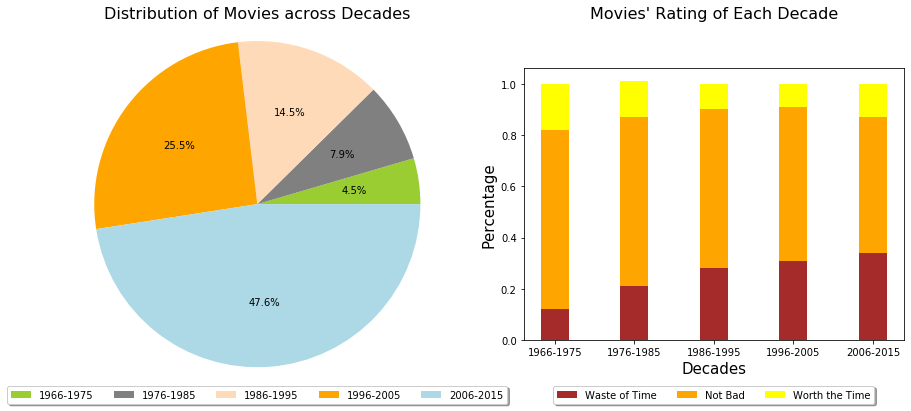

```python
#plot a pie chart that illustrates distribution of movies according to rating
fig5,(ax5,ax4) = plt.subplots(1,2,figsize = (15,5))
decades_share_in_dataset = df_release_year.groupby('decade').id.count()
label_list = ['1966-1975','1976-1985','1986-1995','1996-2005','2006-2015']
ax5.pie(decades_share_in_dataset,colors = ['yellowgreen','gray','peachpuff','orange','lightblue'],radius =1.5,autopct ='%1.1f%%');
ax5.set_title('Distribution of Movies across Decades',size = 16, pad = 50)
ax5.legend(loc='upper center',labels = label_list,  bbox_to_anchor=(0.5, -0.15), fancybox=True, shadow=True,ncol=5)

#Determin how movies of each decade are percieved concerning content quality (rating category)
movie_count_per_decade_per_review = df_review_per_decade.groupby(['decade','review']).id.count()
movie_count_per_decade_per_review = movie_count_per_decade_per_review.astype(float)
decade_list = list(movie_count_per_decade_per_review.index.get_level_values('decade').unique().copy())
for decade in decade_list:
    movie_count_per_decade_per_review[decade] = (movie_count_per_decade_per_review[decade]/movie_count_per_decade_per_review[decade].sum()).round(2)

#plot a bar chart that illustrates how movies of each decade are percieved concerning content quality (rating category)
bar_waste_of_time = movie_count_per_decade_per_review[:,'Waste of time']
bar_not_bad = movie_count_per_decade_per_review[:,'Not bad']
bar_worth_the_time = movie_count_per_decade_per_review[:,'Worth the time']
x_locations = np.arange(len(decade_list))
bar_width = 0.35
labels_list = ['1966-1975','1976-1985','1986-1995','1996-2005','2006-2015']
ax4.bar(x_locations, bar_waste_of_time, width = bar_width, color = 'brown', label =  'Waste of Time')
ax4.bar(x_locations, bar_not_bad, width = bar_width, color = 'orange', label =  'Not Bad', bottom = bar_waste_of_time)
ax4.bar(x_locations, bar_worth_the_time, width = bar_width, color = 'yellow', label =  'Worth the Time', bottom = bar_not_bad + bar_waste_of_time)
plt.xticks(x_locations,labels_list)
plt.xlabel('Decades',size = 15)
plt.ylabel('Percentage',size = 15)
ax4.set_title("Movies' Rating of Each Decade",size = 16, pad = 50)
plt.legend(loc='upper center', bbox_to_anchor=(0.5, -0.15), fancybox=True, shadow=True,ncol=3);
```

> Seems like if you choose an old movie (released: 1966-1975) chances of it being a total trash are pretty low. You even have a 20% chance of ending up watching a really good movie. However, this category doesn't offer a big selection. However, number of old movies available in dataset is rather small. choice: (relative) certainty vs. Options.  
> If you're not up for a disappointment, best to avoid movies released between 2006-2015. But overall, there exists a good portion of movies in each decade that won't waste one's time.

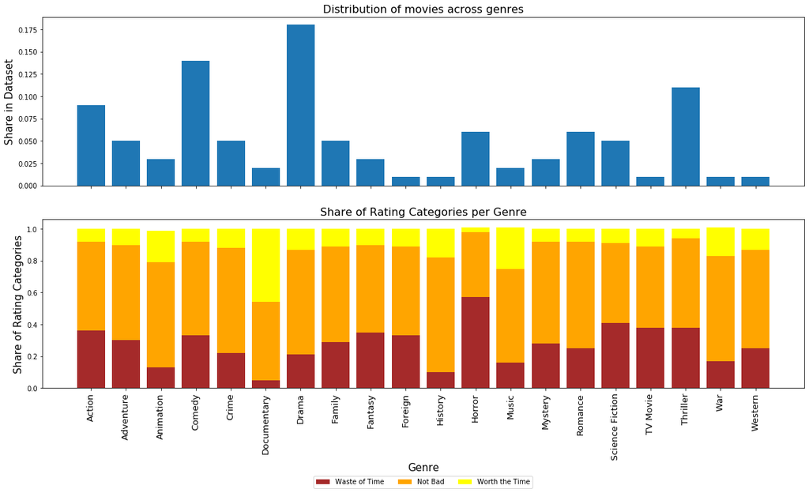

```python
#plot a bar chart that illustrates distribution of movies across to genres
fig, (ax,ax7) = plt.subplots(2,1, sharex = True,figsize = (20,10))
movie_count_per_genre = df_genres.groupby('genre').id.count().copy()
movie_proportion_per_genre = (movie_count_per_genre/df_genres.shape[0]).round(2)
x_locations2 = np.arange(df_genres.genre.nunique())
xtick_labels_genre = list(movie_count_per_genre.index.get_level_values('genre').unique())
ax.bar(x_locations2, movie_proportion_per_genre)
ax.set_ylabel('Share in Dataset',size = 15)
ax.set_title('Distribution of movies across genres' , size =16)

#Determin how movies of each genre are percieved concerning content quality (rating category)
df_review_per_genre = pd.merge(df_review,df_genres, how = 'inner', left_on = 'id', right_on = 'id').copy()
review_count_per_genre = df_review_per_genre.groupby(['genre','review']).id.count()
review_count_per_genre =review_count_per_genre.astype(float)
genre_list = list(df_genres.genre.unique())
for genre in genre_list:
    review_count_per_genre[genre] = (review_count_per_genre[genre]/review_count_per_genre[genre].sum()).round(2)

#plot a bar chart that illustrates how movies of each genre are are percieved concerning content quality (rating category)
bar_waste_of_time7 = review_count_per_genre[:,'Waste of time']
bar_not_bad7 = review_count_per_genre[:,'Not bad']
bar_worth_the_time7 = review_count_per_genre[:,'Worth the time']
x_locations7 = np.arange(len(genre_list))
bar_width7 = 0.60
labels_list7 = xtick_labels_genre
ax7.bar(x_locations7, bar_waste_of_time7,  color = 'brown', label =  'Waste of Time')
ax7.bar(x_locations7, bar_not_bad7,  color = 'orange', label =  'Not Bad', bottom = bar_waste_of_time7)
ax7.bar(x_locations7, bar_worth_the_time7,  color = 'yellow', label =  'Worth the Time', bottom = bar_not_bad7 + bar_waste_of_time7)

plt.xticks(x_locations7,labels_list7, rotation = '90',size=13)
plt.xlabel('Genre',size = 15)
plt.ylabel('Share of Rating Categories',size = 15)
plt.legend(loc='upper center', bbox_to_anchor=(0.5, -0.5), fancybox=True, ncol=3)
plt.title("Share of Rating Categories per Genre" , size =16);
```

## Question 2: Is it a good idea to invest in movie production? If so, how to maximise your chances of success?

. **What are the chances of succeeding?**</strong>  
. **Does initial investment guarantee financial success?**</strong>  
. **Does content quality bring in more profit?** </strong>  
. **And which genre(s) is/are the most promising of all?**</strong>

### What are the chances of succeeding?

In this analysis odds of success is measured in accordance with the profit made.

```python
#Calculate profit:revenue_adj - budget_adj
df_movies['profit'] = df_movies['revenue_adj'] - df_movies['budget_adj']
profit_median = df_movies['profit'].median()
df_movies['profit'].describe()
```

```
count    1.084100e+04
mean     7.847624e+07
std      1.232290e+08
min     -4.139124e+08
25%      1.417362e+07
50%      6.471844e+07
75%      9.925852e+07
max      2.750137e+09
Name: profit, dtype: float64
```

```python
#label movies according to the profit categories: 'Loss','Low Profit','Medium Profit','Moderately High Profit','High Profit'
profit_bin_cut = [-4.14e+08,0,1.42e+07,profit_median,9.93e+07,2.8e+09]
profit_labels = ['Loss','Low Profit','Medium Profit','Moderately High Profit','High Profit']
df_movies['profit_label'] = pd.cut(df_movies['profit'], bins = profit_bin_cut, labels = profit_labels )
#Calculate share of each profit category in the dataset
profit_distribution = df_movies.groupby('profit_label').id.count()
```

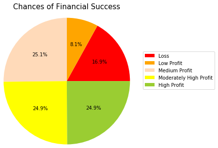

```python
#plot a pie chart that illustrates share of each profit category in the dataset
fig_profit, ax_profit = plt.subplots()
ax_profit.pie(profit_distribution,radius = 1.5, colors = ['red','orange','peachpuff','yellow','yellowgreen'],autopct = '%1.1f%%')
ax_profit.legend(labels =profit_labels,loc='center left', bbox_to_anchor=(1.2, 0.6))
ax_profit.set_title('Chances of Financial Success',size = 15,pad = 40);
```

### Does initial investment guarauntee financial success?

#### Relationship between budget and revenue and profit

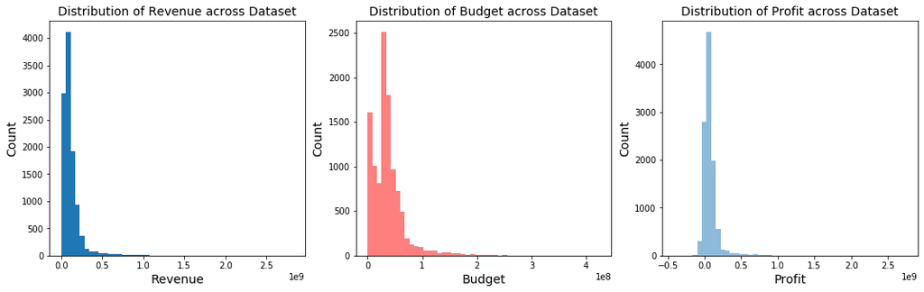

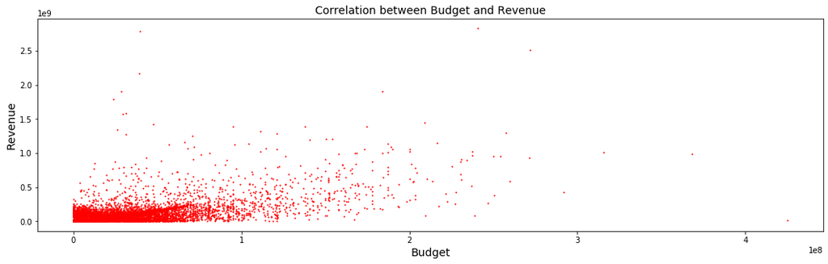

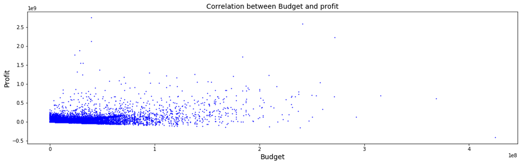

```python
df_revenue_n_budget = df_movies[['id','revenue_adj','budget_adj','profit']].copy()
fig_revenue,(ax_revenue,ax_budget,ax_profit) = plt.subplots (1,3,figsize = (18,5))
ax_revenue.hist(df_revenue_n_budget.revenue_adj, bins = 50)
ax_revenue.set_xlabel('Revenue',size = 14)
ax_revenue.set_ylabel('Count',size = 14)
ax_revenue.set_title('Distribution of Revenue across Dataset',size = 14)
ax_budget.hist(df_revenue_n_budget.budget_adj, bins = 50,color ='red', alpha = 0.5)
ax_budget.set_xlabel('Budget',size = 14)
ax_budget.set_ylabel('Count',size = 14)
ax_budget.set_title('Distribution of Budget across Dataset',size = 14)
ax_profit.hist(df_revenue_n_budget.profit, bins = 50,alpha = 0.5)
ax_profit.set_xlabel('Profit',size = 14)
ax_profit.set_ylabel('Count',size = 14)
ax_profit.set_title('Distribution of Profit across Dataset',size = 14)
fig_corr,ax_corr = plt.subplots (figsize = (18,5))
ax_corr.plot(df_revenue_n_budget.budget_adj,df_revenue_n_budget.revenue_adj,'ro',markersize=1)
ax_corr.set_ylabel('Revenue',size = 14)
ax_corr.set_xlabel('Budget',size = 14)
ax_corr.set_title('Correlation between Budget and Revenue',size = 14)

fig_corr2,ax_corr2 = plt.subplots (figsize = (18,5))
ax_corr2.plot(df_revenue_n_budget.budget_adj,df_revenue_n_budget.profit,'bo',markersize= 1)
ax_corr2.set_ylabel('Profit',size = 14)
ax_corr2.set_xlabel('Budget',size = 14)
ax_corr2.set_title('Correlation between Budget and profit',size = 14);
```

> There is a weak correlation between money invested and profit made.

### Does content quality bring in more profit?

[figure not shown]

```python
fig_corr_profit_rating,(ax_corr_profit_rating, ax_corr_budget_rating )= plt.subplots (2,1,figsize = (18,10))
df_profit_n_rating = df_movies[['id','vote_average','profit']].copy()
ax_corr_profit_rating.plot(df_profit_n_rating.vote_average,df_profit_n_rating.profit,'bo',markersize=2)
ax_corr_profit_rating.set_ylabel('Profit',size = 14)
ax_corr_profit_rating.set_xlabel('Rating',size = 14)
ax_corr_profit_rating.set_title('Correlation between Rating and Profit',size = 14)

df_budget_n_rating = df_movies[['id','vote_average','budget_adj']].copy()
ax_corr_budget_rating.plot(df_budget_n_rating.budget_adj,df_budget_n_rating.vote_average,'bo',markersize=0.2)
ax_corr_budget_rating.set_xlabel('Budget',size = 14)
ax_corr_budget_rating.set_ylabel('Rating',size = 14)
ax_corr_budget_rating.set_title('Correlation between Rating and Profit',size = 14);
```

> There is a relatively stronger correlation between rating and profit. As the rating surpasses 5.5 the profit startts to increase with further improvement in rating. And as can be seen the positive impact of increased budget on rating is noticable in a small set of movies and the correlation is rather weak.

### Which genre(s) are the safest/best bet for investment?

```python
#Determine how each genre does regarding profit
df_profit= df_movies[['id','profit','profit_label']]
df_profit_per_genre = pd.merge(df_profit,df_genres, how = 'inner', left_on = 'id', right_on = 'id')
Genres_profitability = df_profit_per_genre.groupby(['genre','profit_label']).id.count()
Genres_profitability = Genres_profitability.astype(float)
for genre in genre_list:
    Genres_profitability[genre] = (Genres_profitability[genre]/Genres_profitability[genre].sum()).round(2)
Genres_profitability
```

```
genre    profit_label
Action   Loss                      0.18
         Low Profit                0.05
         Medium Profit             0.11
         Moderately High Profit    0.22
         High Profit               0.43
                                   ...
Western  Loss                      0.18
         Low Profit                0.03
         Medium Profit             0.21
         Moderately High Profit    0.33
         High Profit               0.25
Name: id, Length: 100, dtype: float64
```

```python
#Calculate average budget for each genre
df_budget= df_movies[['id','budget_adj']]
df_budget_per_genre = pd.merge(df_budget,df_genres, how = 'inner', left_on = 'id', right_on = 'id')
Genres_budget = df_budget_per_genre.groupby(['genre']).budget_adj.mean()
```

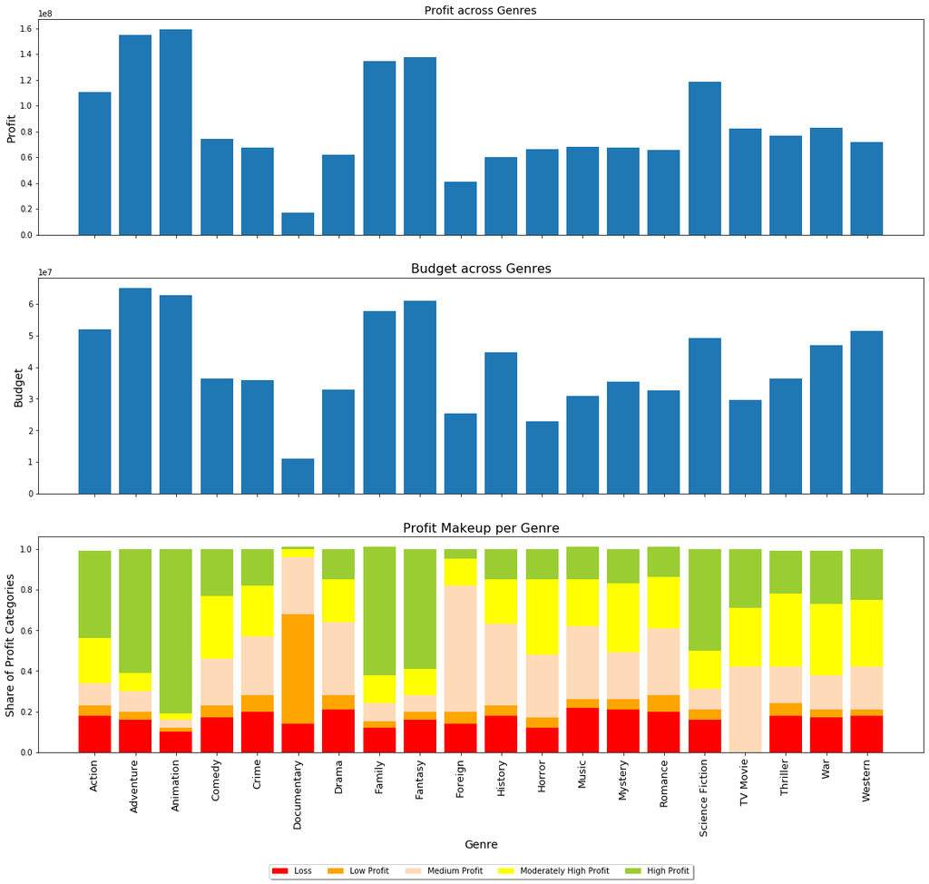

```python
#calculate proportions
bar_loss = Genres_profitability[:,'Loss']
bar_l_profit = Genres_profitability[:,'Low Profit']
bar_m_profit = Genres_profitability[:,'Medium Profit']
bar_mh_profit = Genres_profitability[:,'Moderately High Profit']
bar_h_profit = Genres_profitability[:,'High Profit']
xticks_labels = list(Genres_profitability.index.get_level_values('genre').unique())
xticks_location = np.arange(len(xticks_labels))

fig, (ax_profit_per_genre, ax_budget_per_genre,ax_genre_profit_makeup) = plt.subplots(3,1 ,sharex = True, figsize = (20,17))
#plot a bar chart that illustrates average profit in each genre

profit_per_genre = df_profit_per_genre.groupby('genre').mean().profit.copy()
ax_profit_per_genre.bar(xticks_location ,profit_per_genre)
ax_profit_per_genre.set_title("Profit across Genres",size = 14 );
ax_profit_per_genre.set_ylabel("Profit", size = 14)

#plot a bar chart that illustrates how well each genre does in terms of profit

ax_genre_profit_makeup.bar(xticks_location, bar_loss, color = 'red', label =  'Loss')
ax_genre_profit_makeup.bar(xticks_location, bar_l_profit, color = 'orange', label =  'Low Profit', bottom = bar_loss)
ax_genre_profit_makeup.bar(xticks_location, bar_m_profit, color = 'peachpuff', label =  'Medium Profit', bottom = bar_l_profit + bar_loss )
ax_genre_profit_makeup.bar(xticks_location, bar_mh_profit, color = 'yellow', label =  'Moderately High Profit', bottom = bar_m_profit + bar_l_profit + bar_loss)
ax_genre_profit_makeup.bar(xticks_location, bar_h_profit,  color = 'yellowgreen', label =  'High Profit', bottom = bar_mh_profit + bar_m_profit + bar_l_profit + bar_loss)

plt.xticks(xticks_location,xticks_labels, size=13 ,rotation = '90')
ax_genre_profit_makeup.set_xlabel('Genre',size = 14)
ax_genre_profit_makeup.legend(loc='upper center', bbox_to_anchor=(0.5, -0.5), fancybox=True, shadow=True,ncol=5)
ax_genre_profit_makeup.set_ylabel("Share of Profit Categories", size = 14)
ax_genre_profit_makeup.set_title("Profit Makeup per Genre",size = 16 );
df_budget = df_movies[['id','budget_adj']]
df_budget_genre = pd.merge(df_budget,df_genres, how = 'inner', left_on = 'id', right_on = 'id')

#plot a bar chart that illustrates average budget in each genre

ax_budget_per_genre.bar(xticks_location ,Genres_budget)
ax_budget_per_genre.set_title("Budget across Genres",size = 16 );
ax_budget_per_genre.set_ylabel("Budget", size = 14);
```

# Conclusions

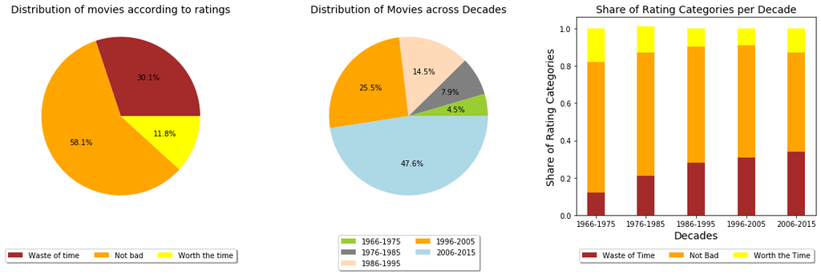

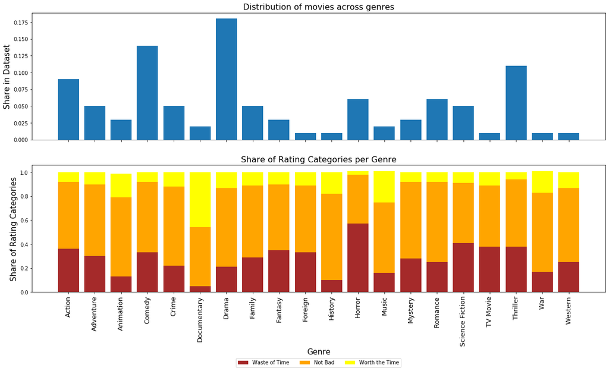

```python
fig, (ax1,ax2,ax3) = plt.subplots(1,3, figsize = (20,5))
ax3.bar(x_locations, bar_waste_of_time, width = bar_width, color = 'brown', label =  'Waste of Time')
ax3.bar(x_locations, bar_not_bad, width = bar_width, color = 'orange', label =  'Not Bad', bottom = bar_waste_of_time)
ax3.bar(x_locations, bar_worth_the_time, width = bar_width, color = 'yellow', label =  'Worth the Time', bottom = bar_not_bad + bar_waste_of_time)
ax3.set_xticks(x_locations)
ax3.set_xticklabels(label_list)
ax3.set_xlabel('Decades',size = 14)
ax3.legend(loc='upper center', bbox_to_anchor=(0.5, -0.15), fancybox=True, shadow=True,ncol=5)
ax3.set_ylabel("Share of Rating Categories", size = 14)
ax3.set_title("Share of Rating Categories per Decade",size = 14 )


ax2.pie(decades_share_in_dataset,colors = ['yellowgreen','gray','peachpuff','orange','lightblue'],autopct ='%1.1f%%')
ax2.set_title('Distribution of Movies across Decades',size = 14)
ax2.legend(loc='upper center',labels = label_list,  bbox_to_anchor=(0.5, -0.08), fancybox=True, shadow=True,ncol=2)
ax1.pie(movie_count_per_review_label,colors = ['brown','orange','yellow'],autopct='%1.1f%%')
ax1.set_title('Distribution of movies according to ratings',  size = 14)
ax1.legend(labels = ['Waste of time', 'Not bad', 'Worth the time'], loc='upper center', bbox_to_anchor=(0.5, -0.15), fancybox=True, shadow=True,ncol=3);
fig, (ax8,ax9) = plt.subplots(2,1, sharex = True, figsize = (20,10))
ax8.bar(x_locations2, movie_proportion_per_genre)
ax8.set_ylabel('Share in Dataset',size = 15)
ax8.set_title('Distribution of movies across genres' , size =16);
x_locations8 = x_locations7
ax9.bar(x_locations8, bar_waste_of_time7,  color = 'brown', label =  'Waste of Time')
ax9.bar(x_locations8, bar_not_bad7,  color = 'orange', label =  'Not Bad', bottom = bar_waste_of_time7)
ax9.bar(x_locations8, bar_worth_the_time7,  color = 'yellow', label =  'Worth the Time', bottom = bar_not_bad7 + bar_waste_of_time7)
plt.xticks(x_locations8,labels_list7, rotation = '90',size=13)
plt.xlabel('Genre',size = 15)
plt.ylabel('Share of Rating Categories',size = 15)
plt.legend(loc='upper center', bbox_to_anchor=(0.5, -0.5), fancybox=True, ncol=3)
ax9.set_title("Share of Rating Categories per Genre" , size =16);
```

### Question 1 - Overall Conclusion:

> Nevertheless, this is by no means an indication that back in the time better movies were produced. The number of older movies in this dataset is significantly lower.Therefore, it cannot be a very reliable sample size. Moreover, people tend to watch old movies only when it is strongly recommended by others, therefore the ones that got reviewed on Imdb perhaps were anyway on the higher end to begin with.

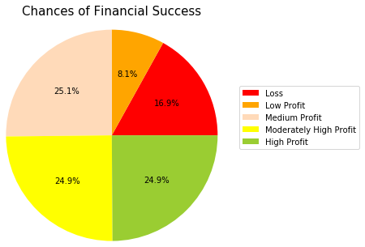

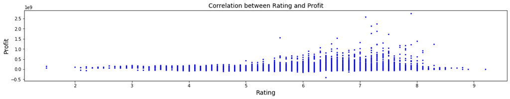

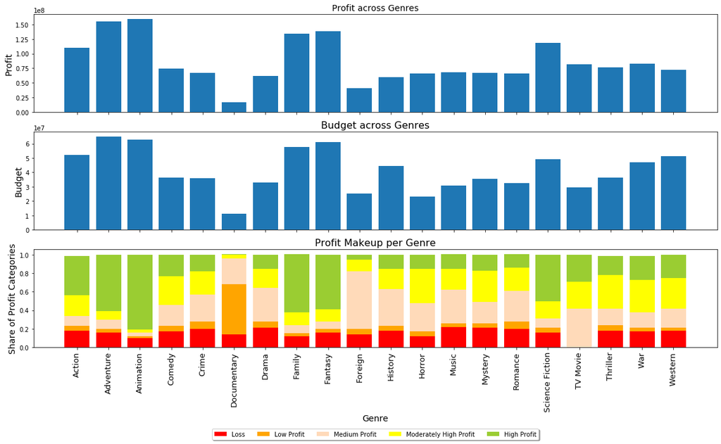

```python
#plot a pie chart that illustrates share of each profit category in the dataset
fig_profit, ax_profit = plt.subplots()
ax_profit.pie(profit_distribution,radius = 1.5, colors = ['red','orange','peachpuff','yellow','yellowgreen'],autopct = '%1.1f%%')
ax_profit.legend(labels =profit_labels,loc='center left', bbox_to_anchor=(1.2, 0.6))
ax_profit.set_title('Chances of Financial Success',size = 15,pad = 40);

fig_corr_profit_rating,ax_corr_profit_rating= plt.subplots (figsize = (20,3))
df_profit_n_rating = df_movies[['id','vote_average','profit']].copy()
ax_corr_profit_rating.plot(df_profit_n_rating.vote_average,df_profit_n_rating.profit,'bo',markersize=2)
ax_corr_profit_rating.set_ylabel('Profit',size = 14)
ax_corr_profit_rating.set_xlabel('Rating',size = 14)
ax_corr_profit_rating.set_title('Correlation between Rating and Profit',size = 14)

fig, (ax_profit_per_genre, ax_budget_per_genre,ax_genre_profit_makeup) = plt.subplots(3,1 ,sharex = True, figsize = (20,10))
#plot a bar chart that illustrates average profit in each genre

profit_per_genre = df_profit_per_genre.groupby('genre').mean().profit.copy()
ax_profit_per_genre.bar(xticks_location ,profit_per_genre)
ax_profit_per_genre.set_title("Profit across Genres",size = 14 );
ax_profit_per_genre.set_ylabel("Profit", size = 14)

#plot a bar chart that illustrates how well each genre does in terms of profit

ax_genre_profit_makeup.bar(xticks_location, bar_loss, color = 'red', label =  'Loss')
ax_genre_profit_makeup.bar(xticks_location, bar_l_profit, color = 'orange', label =  'Low Profit', bottom = bar_loss)
ax_genre_profit_makeup.bar(xticks_location, bar_m_profit, color = 'peachpuff', label =  'Medium Profit', bottom = bar_l_profit + bar_loss )
ax_genre_profit_makeup.bar(xticks_location, bar_mh_profit, color = 'yellow', label =  'Moderately High Profit', bottom = bar_m_profit + bar_l_profit + bar_loss)
ax_genre_profit_makeup.bar(xticks_location, bar_h_profit,  color = 'yellowgreen', label =  'High Profit', bottom = bar_mh_profit + bar_m_profit + bar_l_profit + bar_loss)

plt.xticks(xticks_location,xticks_labels, size=13 ,rotation = '90')
ax_genre_profit_makeup.set_xlabel('Genre',size = 14)
ax_genre_profit_makeup.legend(loc='upper center', bbox_to_anchor=(0.5, -0.8), fancybox=True, shadow=True,ncol=5)
ax_genre_profit_makeup.set_ylabel("Share of Profit Categories", size = 14)
ax_genre_profit_makeup.set_title("Profit Makeup per Genre",size = 16 );
df_budget = df_movies[['id','budget_adj']]
df_budget_genre = pd.merge(df_budget,df_genres, how = 'inner', left_on = 'id', right_on = 'id')

#plot a bar chart that illustrates average budget in each genre

ax_budget_per_genre.bar(xticks_location ,Genres_budget)
ax_budget_per_genre.set_title("Budget across Genres",size = 16 );
ax_budget_per_genre.set_ylabel("Budget", size = 14);
```

### Q2 - Overall Conclusion

> One interesting genre is TV Movies. Though 40% of the movies in this genre are voted by the viewers as waste of time. One would not lose money by producing movies of this genre. So perhaps the right management of distribution means higher sales and therefore higher profit.

**Overall conclusion would be that investment is a profitable business. Safest bet with lower budget required would be producing TV Movies, best bet in case capital is available is to produce Animation or Adventure movies.**